# Advanced DNA Sequence Analysis Report

2026-04-14

# Introduction

This report compares three DNA sequences from Mexico, Wuhan, and Francia. It summarizes genome metrics, identifies pairwise differences, visualizes mutation patterns, and builds a simple phylogenetic tree.

# 1. Load Data

```r
mexico <- read.fasta(file.path(assets_dir, "mexico.fasta"))[[1]]
wuhan <- read.fasta(file.path(assets_dir, "wuhan.fasta"))[[1]]
francia <- read.fasta(file.path(assets_dir, "francia.fasta"))[[1]]
```

# 2. Basic Metrics

The table below summarizes sequence length and GC content for each sample.

```r
summary_df <- data.frame(
  Sample = c("Mexico", "Wuhan", "Francia"),
  Length = c(length(mexico), length(wuhan), length(francia)),
  GC = c(GC(mexico), GC(wuhan), GC(francia)) * 100
)

summary_df
```

```
##    Sample Length       GC
## 1  Mexico  29855 38.00703
## 2   Wuhan  29903 37.97278
## 3 Francia  29804 38.01839
```

# 3. Mutation Analysis

This section computes pairwise differences between sequences and stores the positions where the nucleotides differ.

```r
compare_sequences <- function(seq1, seq2, name1, name2) {
  min_len <- min(length(seq1), length(seq2))
  diffs <- seq1[1:min_len] != seq2[1:min_len]

  data.frame(
    Position = which(diffs),
    Seq1 = seq1[1:min_len][diffs],
    Seq2 = seq2[1:min_len][diffs],
    Comparison = paste(name1, "vs", name2)
  )
}

mex_wuh <- compare_sequences(mexico, wuhan, "Mexico", "Wuhan")
mex_fra <- compare_sequences(mexico, francia, "Mexico", "Francia")
wuh_fra <- compare_sequences(wuhan, francia, "Wuhan", "Francia")

mutations <- bind_rows(mex_wuh, mex_fra, wuh_fra)

head(mutations)
```

```
##   Position Seq1 Seq2      Comparison
## 1        1    g    a Mexico vs Wuhan
## 2        2    g    t Mexico vs Wuhan
## 3        4    t    a Mexico vs Wuhan
## 4        5    t    a Mexico vs Wuhan
## 5        7    t    g Mexico vs Wuhan
## 6        8    a    g Mexico vs Wuhan
```

# 4. Mutation Density Plot

The histogram shows how mutation positions are distributed along the genome.

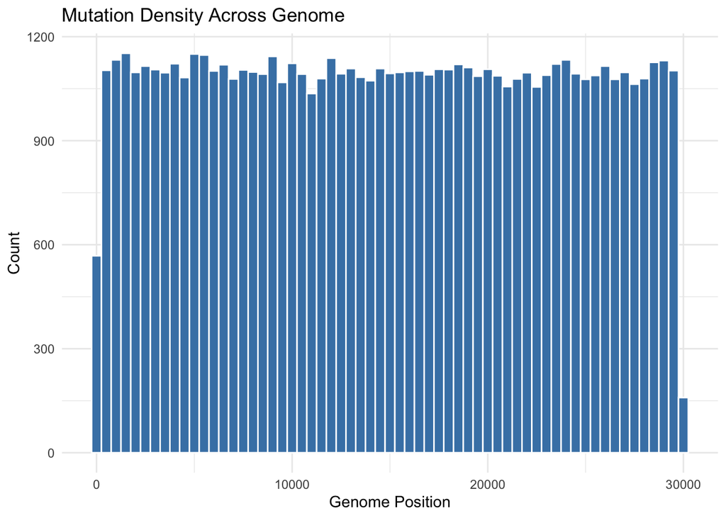

```r
ggplot(mutations, aes(x = Position)) +
  geom_histogram(binwidth = 500, fill = "steelblue", color = "white") +
  theme_minimal() +
  labs(
    title = "Mutation Density Across Genome",
    x = "Genome Position",
    y = "Count"
  )
```

# 5. Position-wise Variation Map

This plot marks nucleotide mismatches between the Mexico and Wuhan sequences.

[figure not shown]

```r
variation_vector <- function(seq1, seq2) {
  min_len <- min(length(seq1), length(seq2))
  as.numeric(seq1[1:min_len] != seq2[1:min_len])
}

var_mex_wuh <- variation_vector(mexico, wuhan)

plot(
  var_mex_wuh,
  type = "l",
  main = "Variation Map: Mexico vs Wuhan",
  ylab = "Mutation (1 = different)",
  xlab = "Position"
)
```

# 6. Distance Matrix

The matrix below contains the number of nucleotide differences between each pair of sequences.

```r
seqs <- list(mexico, wuhan, francia)
sample_names <- c("Mexico", "Wuhan", "Francia")

dist_matrix <- matrix(0, nrow = 3, ncol = 3)
rownames(dist_matrix) <- sample_names
colnames(dist_matrix) <- sample_names

for (i in seq_along(seqs)) {
  for (j in seq_along(seqs)) {
    min_len <- min(length(seqs[[i]]), length(seqs[[j]]))
    dist_matrix[i, j] <- sum(seqs[[i]][1:min_len] != seqs[[j]][1:min_len])
  }
}

dist_matrix
```

```
##         Mexico Wuhan Francia
## Mexico       0 21506   22047
## Wuhan    21506     0   22091
## Francia  22047 22091       0
```

# 7. Phylogenetic Tree

The neighbor-joining tree provides a simple view of sequence similarity.

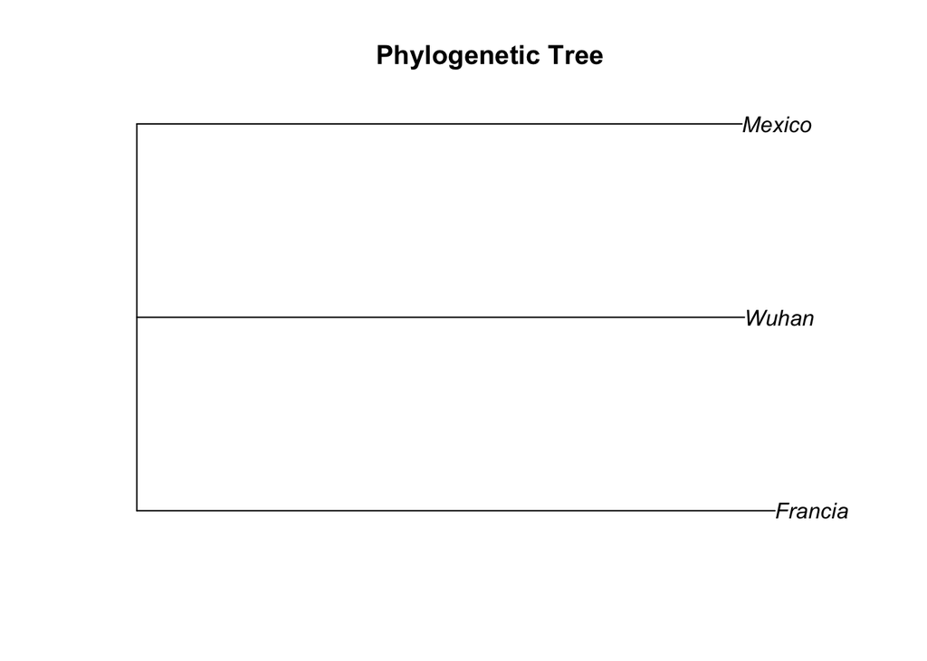

```r
dist_obj <- as.dist(dist_matrix)
tree <- nj(dist_obj)

plot(tree, main = "Phylogenetic Tree")
```

# 8. Optional Sequence Alignment

If you want to perform a formal alignment, you can use the optional code below. It is disabled by default because it requires the `DECIPHER` package.

```r
if (!all(optional_package_status[c("DECIPHER", "Biostrings")])) {
  stop("Install 'DECIPHER' and 'Biostrings' to run the alignment section.")
}

dna_set <- Biostrings::DNAStringSet(c(
  Mexico = paste(mexico, collapse = ""),
  Wuhan = paste(wuhan, collapse = ""),
  Francia = paste(francia, collapse = "")
))

alignment <- DECIPHER::AlignSeqs(dna_set)

DECIPHER::BrowseSeqs(alignment)
```

# 9. Reverse Complement Utility

This helper function returns the reverse complement of a DNA sequence.

```r
reverse_complement <- function(seq) {
  rev(comp(seq))
}
```

# 10. Interpretation Guide

- Mutation clusters may suggest possible hotspots.
- Low pairwise distances indicate closely related strains.
- Tree topology provides a simple view of evolutionary relationships.
- GC content can be used as a rough indicator of genome stability.